# EP11-respuesta-equipo-6

2025-06-12

Se realizó la carga de datos y se calculó el IMC y la variable dicotómica EN (estado nutricional) de acuerdo al valor de IMC de cada persona. Se consideró sobrepeso cuando el IMC es mayor o igual a 23.2, y no sobrepeso cuando es menor a este valor. La variable EN toma el valor 1 para sobrepeso y 0 para no sobrepeso. Finalmente, se añadió la variable EN al conjunto de datos original.

```r
data = read.csv2("EP09 Datos.csv",sep = ";")
peso = data$Weight
altura = data$Height
imc = peso/(altura/100)^2
data = cbind(data,imc)
en = imc
for (i in imc) {
  if(i>=23.2){
    en[en == i] = 1
  } else {
    en[en == i] = 0
  }
}
#1: sobrepeso 0: no sobrepeso
data = cbind(data,en)
data$en = factor(data$en)
```

### Seleccionar una muestra de 100 personas, asegurando que la mitad tenga estado nutricional “sobrepeso” y la otra mitad “no sobrepeso”.

```r
set.seed(19647)
muestra = data %>% group_by(en) %>% sample_n(50)
muestra = muestra[sample(nrow(muestra)), ]  #desordena la muestra para que los valores de EN no estén ordenados
```

### Usando las herramientas del paquete leaps, realizar una búsqueda exhaustiva para seleccionar entre dos y ocho predictores que ayuden a estimar la variable Peso (Weight), obviamente sin considerar las nuevas variables IMC ni EN, y luego utilizar las funciones del paquete caret para construir un modelo de regresión lineal múltiple con los predictores escogidos y evaluarlo usando bootstrapping.

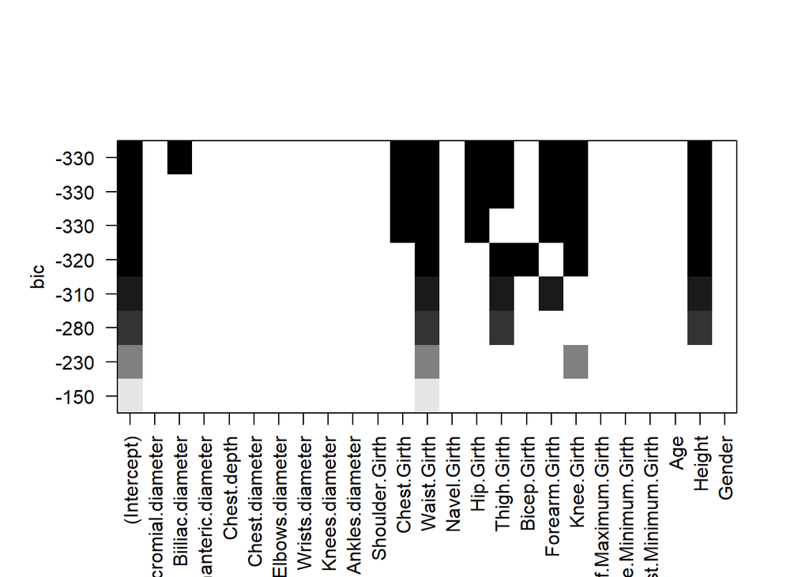

```r
set.seed(19647)
variables_predictoras = colnames(muestra)
variables_predictoras = setdiff(variables_predictoras, c("Weight", "imc", "en"))

data_exaustiva = muestra[, c("Weight",variables_predictoras)]
combinaciones = regsubsets(Weight ~ ., data = data_exaustiva, nbest = 1, nvmax = 8, method = "exhaustive")

#Graficar resultados
plot(combinaciones)
```

```r
#Extraer los mejores subconjuntos

resumen_combinaciones <- summary(combinaciones)

i_bic_minimo <- which.min(resumen_combinaciones[["bic"]])
i_r2a_maximo <- which.max(resumen_combinaciones[["adjr2"]])

mejor_comb_bic <- resumen_combinaciones[["which"]][i_bic_minimo, ]
mejor_comb_r2a <- resumen_combinaciones[["which"]][i_r2a_maximo, ]

# Extraer las variables seleccionadas
comb_mejor_bic <- names(mejor_comb_bic[mejor_comb_bic == TRUE])[-1]  # Exclude intercept
comb_mejor_r2a <- names(mejor_comb_r2a[mejor_comb_r2a == TRUE])[-1]  # Exclude intercept

# Mostrar mejores modelos

cat("Mejores predictores (BIC):", comb_mejor_bic, "\n")
```

```
## Mejores predictores (BIC): Biiliac.diameter Chest.Girth Waist.Girth Hip.Girth Thigh.Girth Forearm.Girth Knee.Girth Height
```

```r
cat("Mejores predictores (R2 adjusted):", comb_mejor_r2a, "\n")
```

```
## Mejores predictores (R2 adjusted): Biiliac.diameter Chest.Girth Waist.Girth Hip.Girth Thigh.Girth Forearm.Girth Knee.Girth Height
```

```r
# data para entrenamiento con los mejores predictores, acá se encuentran las 100 observaciones y solo los mejores predictores
train_r2a <- muestra[, c("Weight", comb_mejor_r2a)]

# Definir control de entrenamiento para bootstrapping
train_control <- trainControl(method = "boot", number = 1000)


# Entrenar regresión lineal
modelo_mejor_r2a <- train(Weight ~ ., data = train_r2a,
                          method = "lm",
                          trControl = train_control)
print(modelo_mejor_r2a)
```

```
## Linear Regression
##
## 100 samples
##   8 predictor
##
## No pre-processing
## Resampling: Bootstrapped (1000 reps)
## Summary of sample sizes: 100, 100, 100, 100, 100, 100, ...
## Resampling results:
##
##   RMSE      Rsquared   MAE
##   2.328738  0.9695214  1.853933
##
## Tuning parameter 'intercept' was held constant at a value of TRUE
```

```r
# Extraer y mostrar resultados del modelo
resultados <- modelo_mejor_r2a$results
cat("RMSE ", resultados$RMSE, "\n")
```

```
## RMSE  2.328738
```

```r
cat("R-squared:", resultados$Rsquared, "\n")
```

```
## R-squared: 0.9695214
```

```r
summary(modelo_mejor_r2a)
```

```
##
## Call:
## lm(formula = .outcome ~ ., data = dat)
##
## Residuals:
##     Min      1Q  Median      3Q     Max
## -4.2242 -1.5224  0.1168  1.1870  5.6554
##
## Coefficients:
##                    Estimate Std. Error t value Pr(>|t|)
## (Intercept)      -115.67636    4.92407 -23.492  < 2e-16 ***
## Biiliac.diameter    0.30504    0.13101   2.328  0.02210 *
## Chest.Girth         0.23199    0.05678   4.086 9.45e-05 ***
## Waist.Girth         0.34552    0.04755   7.267 1.23e-10 ***
## Hip.Girth           0.22695    0.08461   2.682  0.00868 **
## Thigh.Girth         0.25653    0.10848   2.365  0.02016 *
## Forearm.Girth       0.74930    0.18228   4.111 8.62e-05 ***
## Knee.Girth          0.51097    0.16605   3.077  0.00276 **
## Height              0.31157    0.03375   9.232 1.03e-14 ***
## ---
## Signif. codes:  0 '***' 0.001 '**' 0.01 '*' 0.05 '.' 0.1 ' ' 1
##
## Residual standard error: 2.118 on 91 degrees of freedom
## Multiple R-squared:  0.9758, Adjusted R-squared:  0.9736
## F-statistic: 457.8 on 8 and 91 DF,  p-value: < 2.2e-16
```

### Evaluación de confiabilidad y poder de predicción para el modelo RLM obtenido en parte 3)

### 1. La variable de salida/respuesta debe ser continua y cuantitativa.

### 2. Los predictores deben ser cuantitativos o dicotómicos.

### 3. Los predictores deben tener algun grado de variabilidad, es decir no son constantes

Se cumple que la variable de salida/respuesta es continua y cuantitativa, ya que la variable `Weight` (Peso) es numérica y puede tomar cualquier valor dentro de un rango. Se cumple que los predictores son cuantitativos o dicotómicos, ya que las variables seleccionadas como predictores son todas numéricas y no hay variables categóricas. Se cumple que los predictores tienen algún grado de variabilidad, ya que todas las variables seleccionadas como predictores tienen varianza distinta de cero.

```r
#Codigo respuesta 1.
var(muestra$Weight)
```

```
## [1] 170.0345
```

```r
is.numeric(muestra$Weight)
```

```
## [1] TRUE
```

```r
#Codigo respuesta 2.

var(muestra$Height)
```

```
## [1] 96.24798
```

```r
is.numeric(muestra$Height)
```

```
## [1] TRUE
```

```r
var(muestra$Waist.Girth)
```

```
## [1] 129.7375
```

```r
is.numeric(muestra$Waist.Girth)
```

```
## [1] TRUE
```

```r
var(muestra$Forearm.Girth)
```

```
## [1] 7.913939
```

```r
is.numeric(muestra$Forearm.Girth)
```

```
## [1] TRUE
```

```r
var(muestra$Chest.Girth)
```

```
## [1] 106.2249
```

```r
is.numeric(muestra$Chest.Girth)
```

```
## [1] TRUE
```

```r
var(muestra$Knee.Girth)
```

```
## [1] 6.40737
```

```r
is.numeric(muestra$Knee.Girth)
```

```
## [1] TRUE
```

```r
var(muestra$Hip.Girth)
```

```
## [1] 40.59469
```

```r
is.numeric(muestra$Hip.Girth)
```

```
## [1] TRUE
```

```r
var(muestra$Thigh.Girth)
```

```
## [1] 16.08452
```

```r
is.numeric(muestra$Thigh.Girth)
```

```
## [1] TRUE
```

```r
var(muestra$Biiliac.diameter)
```

```
## [1] 4.355802
```

```r
is.numeric(muestra$Biiliac.diameter)
```

```
## [1] TRUE
```

### 4. Cada predictor debe estar relacionado linealmente con la respuesta.

### 5. La distribución de los residuos debe ser cercana a la normal centrada en cero.

### 6. La variabilidad de los residuos debe ser constante (homocedasticidad).

Analizando los gráficos obtenidos, notamos que existen predictores que no siguen una distribución lineal con la variable de respuesta, en este caso tenemos las variables Biiliac.diameter, Hip.Girth, Chest.Girth y Knee.Girth. Por lo que se evaluará con otras pruebas si es necesario la eliminacion de estas variables o no, con el propósito de encontrar el mejor modelo posible. Por otra parte, los residuos del modelo siguen una distribución normal centrada en cero, ya que el gráfico Q-Q muestra que los puntos se alinean con la línea diagonal, lo que indica que los residuos son aproximadamente normales. Por ultimo el resultado entregado por el test de homoscedasticidad indica que la variabilidad de los residuos es constante, dado que el p-valor es mayor a 0.05.

```r
set.seed(19647)

modelofinal <- lm(Weight ~ ., data = train_r2a)

summary(modelofinal)
```

```
##
## Call:
## lm(formula = Weight ~ ., data = train_r2a)
##
## Residuals:
##     Min      1Q  Median      3Q     Max
## -4.2242 -1.5224  0.1168  1.1870  5.6554
##
## Coefficients:
##                    Estimate Std. Error t value Pr(>|t|)
## (Intercept)      -115.67636    4.92407 -23.492  < 2e-16 ***
## Biiliac.diameter    0.30504    0.13101   2.328  0.02210 *
## Chest.Girth         0.23199    0.05678   4.086 9.45e-05 ***
## Waist.Girth         0.34552    0.04755   7.267 1.23e-10 ***
## Hip.Girth           0.22695    0.08461   2.682  0.00868 **
## Thigh.Girth         0.25653    0.10848   2.365  0.02016 *
## Forearm.Girth       0.74930    0.18228   4.111 8.62e-05 ***
## Knee.Girth          0.51097    0.16605   3.077  0.00276 **
## Height              0.31157    0.03375   9.232 1.03e-14 ***
## ---
## Signif. codes:  0 '***' 0.001 '**' 0.01 '*' 0.05 '.' 0.1 ' ' 1
##
## Residual standard error: 2.118 on 91 degrees of freedom
## Multiple R-squared:  0.9758, Adjusted R-squared:  0.9736
## F-statistic: 457.8 on 8 and 91 DF,  p-value: < 2.2e-16
```

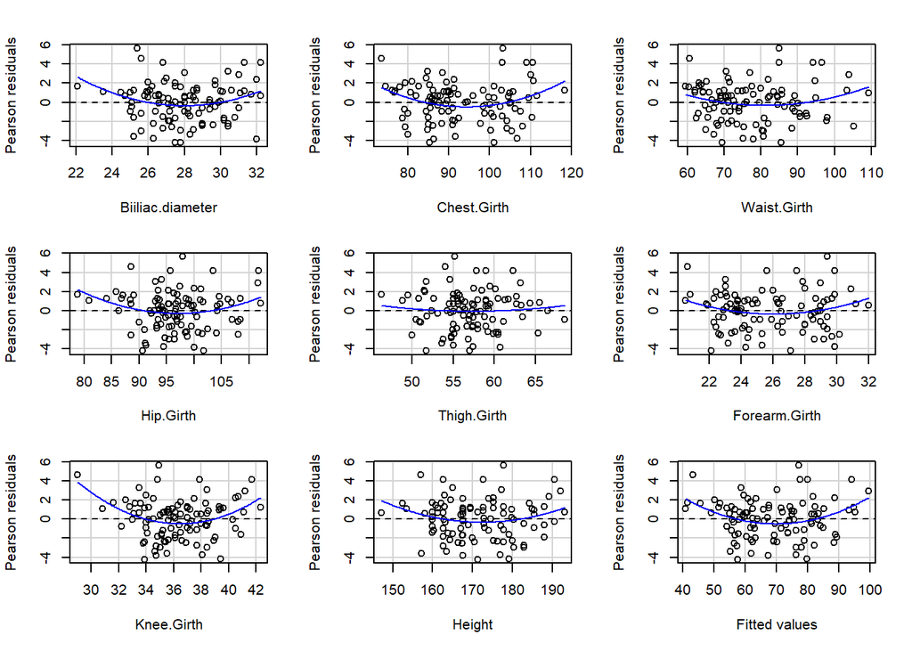

```
##                  Test stat Pr(>|Test stat|)
## Biiliac.diameter    2.3489        0.0210158 *
## Chest.Girth         2.5625        0.0120535 *
## Waist.Girth         1.9089        0.0594676 .
## Hip.Girth           2.4179        0.0176268 *
## Thigh.Girth         0.5649        0.5735408
## Forearm.Girth       1.7262        0.0877424 .
## Knee.Girth          3.6545        0.0004330 ***
## Height              1.9598        0.0531168 .
## Tukey test          3.3169        0.0009101 ***
## ---
## Signif. codes:  0 '***' 0.001 '**' 0.01 '*' 0.05 '.' 0.1 ' ' 1
```

```r
#Linealidad de los predictores
residualPlots(modelofinal)
```

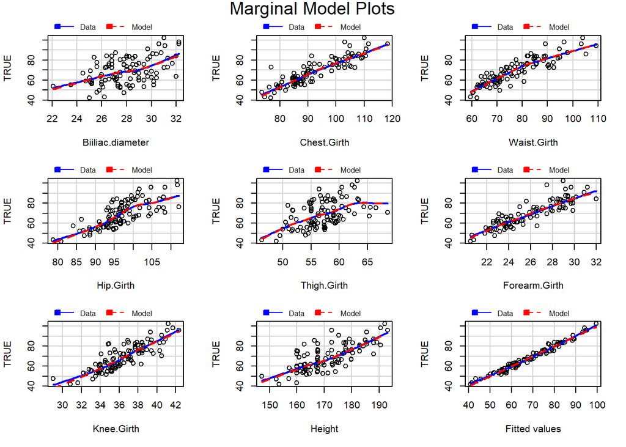

```r
marginalModelPlots(modelofinal)
```

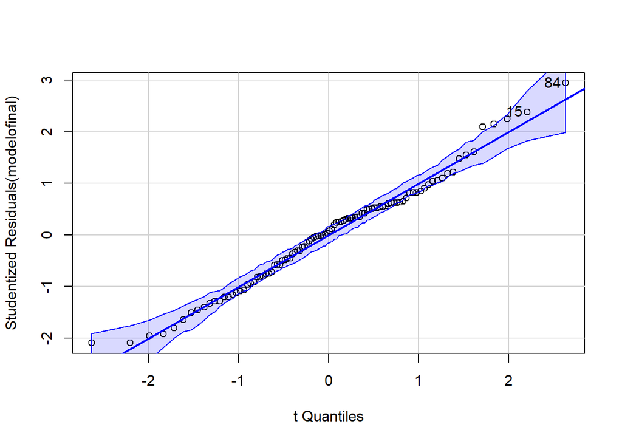

```
## [1] 15 84
```

```r
#Normalidad de los residuos

qqPlot(modelofinal)
```

```r
#Homoscedasticidad de los residuos

ncvTest(modelofinal)
```

```
## Non-constant Variance Score Test
## Variance formula: ~ fitted.values
## Chisquare = 0.4240536, Df = 1, p = 0.51492
```

### 7. Los residuos deben ser independientes entre sí.

```r
set.seed(19647)
durbinWatsonTest(modelofinal)
```

```
##  lag Autocorrelation D-W Statistic p-value
##    1       0.1941359       1.56397   0.018
##  Alternative hypothesis: rho != 0
```

### 8. No debe existir multicolinealidad entre los predictores.

El valor entregado por la funcion VIF indica que exite multicolinealidad entre los predictores del modelo final obtenido, ya que el VIF de algunos de ellos se encuentra en un rango entre 5 y 10, lo cual es una multicolinealidad preocupante que podría afectar significativamente los resultados. Dado esto, se aplicarán medidas correctivas para abordar este problema, como la eliminación de variables altamente correlacionadas o la combinación de variables para reducir la multicolinealidad. Se eliminará en primera instancia la variable Hip.Girth, ya que este predictor tiene relación con la variable Billiac.diameter. Los demás predictores redijeron considerablemente, sin embargo, Chest.Girth sigue entregando un valor alto, por lo cual se procederá a su eliminación.

```r
set.seed(19647)
cat("VIF de los predictores del modelo final obtenido:\n")
```

```
## VIF de los predictores del modelo final obtenido:
```

```r
vif(modelofinal)
```

```
## Biiliac.diameter      Chest.Girth      Waist.Girth        Hip.Girth
##         1.650319         7.560569         6.475045         6.415616
##      Thigh.Girth    Forearm.Girth       Knee.Girth           Height
##         4.178471         5.804610         3.900383         2.420269
```

```r
modelofinaltemp2 <- update(modelofinal, . ~ . - Hip.Girth)
cat("Nuevo VIF luego de eliminar el predictor Hip.Girth:\n")
```

```
## Nuevo VIF luego de eliminar el predictor Hip.Girth:
```

```r
vif(modelofinaltemp2)
```

```
## Biiliac.diameter      Chest.Girth      Waist.Girth      Thigh.Girth
##         1.585593         7.460479         4.916419         1.706285
##    Forearm.Girth       Knee.Girth           Height
##         5.705901         3.874221         2.297153
```

```r
modelofinaltemp3 <- update(modelofinaltemp2, . ~ . - Chest.Girth)
cat("Nuevo VIF luego de eliminar el predictor Chest.Girth:\n")
```

```
## Nuevo VIF luego de eliminar el predictor Chest.Girth:
```

```r
vif(modelofinaltemp3)
```

```
## Biiliac.diameter      Waist.Girth      Thigh.Girth    Forearm.Girth
##         1.524794         2.868127         1.698176         4.112041
##       Knee.Girth           Height
##         3.874079         2.293336
```

```r
cat("Summary del nuevo modelo final obtenido tras la eliminacion de pred\n")
```

```
## Summary del nuevo modelo final obtenido tras la eliminacion de pred
```

```r
summary(modelofinaltemp3)
```

```
##
## Call:
## lm(formula = Weight ~ Biiliac.diameter + Waist.Girth + Thigh.Girth +
##     Forearm.Girth + Knee.Girth + Height, data = train_r2a)
##
## Residuals:
##     Min      1Q  Median      3Q     Max
## -4.9077 -1.5518  0.0782  1.2851  6.8908
##
## Coefficients:
##                    Estimate Std. Error t value Pr(>|t|)
## (Intercept)      -111.50140    5.32259 -20.949  < 2e-16 ***
## Biiliac.diameter    0.27902    0.13859   2.013   0.0470 *
## Waist.Girth         0.50978    0.03483  14.637  < 2e-16 ***
## Thigh.Girth         0.49852    0.07611   6.550 3.14e-09 ***
## Forearm.Girth       1.04872    0.16885   6.211 1.46e-08 ***
## Knee.Girth          0.55128    0.18214   3.027   0.0032 **
## Height              0.33709    0.03616   9.323 5.55e-15 ***
## ---
## Signif. codes:  0 '***' 0.001 '**' 0.01 '*' 0.05 '.' 0.1 ' ' 1
##
## Residual standard error: 2.331 on 93 degrees of freedom
## Multiple R-squared:   0.97,  Adjusted R-squared:  0.9681
## F-statistic:   501 on 6 and 93 DF,  p-value: < 2.2e-16
```

Luego de la corrección del modelo tras la eliminación de los predictores con multicolinealidad, se tiene que los predictores finales se encuentran en un rango entre 1 y 5 de valor VIF, lo cual suguiere una multicolinealidad moderada que puede afectar moderadamente los resultados, pero que no son de gran preocupación. Al aplicar el test de Durbin-Watson al nuevo modelo final, se observa que los residuos del modelo corregido son independientes entre sí, ya que el p-value es mayor a 0.05. Esto sugiere que no hay evidencia suficiente para rechazar la hipótesis nula de independencia de los residuos.

```r
set.seed(19647)
dwt(modelofinaltemp3)
```

```
##  lag Autocorrelation D-W Statistic p-value
##    1       0.1388789      1.695641   0.112
##  Alternative hypothesis: rho != 0
```

### 9. Los valores atípicos no deben influir en el modelo de manera significativa.

El umbral crítico para identificar valores atípicos es 4/n, donde n es el número de observaciones. En este caso, n = 100, por lo que el umbral crítico es 0.04. Las observaciones 23 y 84 se encuentran por sobre el humbral crítico, lo que indica que son valores atípicos. En cuanto a los valores Hat, se tiene que el límite superior es 2*(k+1)/n, donde k es el número de predictores. En este caso, k = 6, por lo que el límite superior es 0.14. Las observaciones 31 y 34 se encuentran por sobre el límite superior, lo que indica que son valores influyentes. Por lo tanto, se tienen 2 valores atípicos y 2 valores influyentes en el modelo final obtenido, lo cual representan el 4% de las observaciones, lo que es un porcentaje aceptable. Por lo tanto, no se eliminarán del modelo final obtenido.

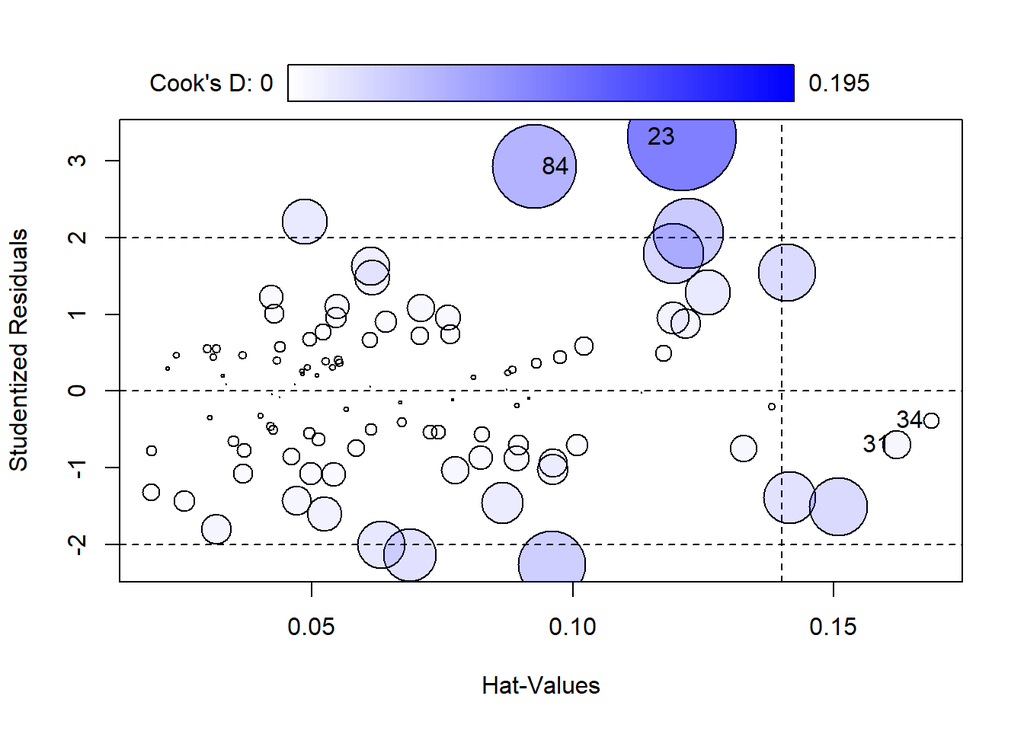

```
##       StudRes        Hat       CookD
## 23  3.3187826 0.12092618 0.195406918
## 31 -0.6986120 0.16210898 0.013564095
## 34 -0.3790903 0.16862898 0.004202831
## 84  2.9321333 0.09259475 0.115864564
```

```r
influencePlot(modelofinaltemp3)
```

### Evaluar el poder predictivo del modelo final obtenido.

Finalmente evaluaremos el poder predictivo del modelo, para esto tendremos una muestr asimilar a la de entrenamiento, 100 observaciones con 50 valores 1 y 50 valores 0 de la variable EN, y con los mismos predictores que el modelo final obtenido.

```r
# Crear una muestra de 100 observaciones con 50 de cada estado nutricional
set.seed(19647)

muestra_pred <- data %>% group_by(en) %>% sample_n(50)
muestra_pred <- muestra_pred[sample(nrow(muestra_pred)), ]

# Seleccionar las mismas variables predictoras que el modelo final
predictores_finales <- names(coef(modelofinaltemp3))[-1]  # Excluye intercepto


test_data <- muestra_pred[, c("Weight", predictores_finales)]

predicciones <- predict(modelofinaltemp3, newdata = test_data)


# Predecir con los datos no utilizados
predicciones <- predict(modelofinaltemp3, newdata = test_data)
# Agregar las predicciones al data frame de los datos no utilizados
test_data$Predicciones <- predicciones
# Mostrar las predicciones
print(test_data[, c("Weight", "Predicciones")])
```

```
## # A tibble: 100 × 2
##    Weight Predicciones
##     <dbl>        <dbl>
##  1   53.4         57.0
##  2   54.5         55.4
##  3   53.6         52.6
##  4   82.7         80.5
##  5   56.2         58.0
##  6   62.2         63.5
##  7   57.8         57.3
##  8   77.7         79.2
##  9   83.2         84.3
## 10   80.9         81.7
## # ℹ 90 more rows
```

```r
# Calcular el error cuadrático medio (MSE)
mse <- mean((test_data$Weight - test_data$Predicciones)^2)
# Calcular el error cuadrático medio (RMSE)
rmse <- sqrt(mse)
cat("RMSE del modelo final:", rmse, "\n")
```

```
## RMSE del modelo final: 2.247639
```

### Haciendo un poco de investigación sobre el paquete caret, en particular cómo hacer Recursive Feature Elimination (RFE), construir un modelo de regresión lineal múltiple para predecir la variable IMC que incluya entre 10 y 20 predictores, seleccionando el conjunto de variables que maximice R2 y que use cinco repeticiones de validación cruzada de cinco pliegues para evitar el sobreajuste (obviamente no se debe considerar las variables Peso, Estatura ni estado nutricional –Weight, Height, EN respectivamente).

las fuentes de investigacion para realizar el modelo son las siguientes:

1.https://www.machinelearningmastery.com/feature-selection-with-the-caret-r-package/

2.https://topepo.github.io/caret/recursive-feature-elimination.html

```r
# 1. predictores (x) y variable respuesta (y)
predictores_imc <- setdiff(colnames(muestra), c("imc", "en", "Weight", "Height"))
x_imc <- muestra[, predictores_imc]
y_imc <- muestra$imc

# Asegurarnos de que no haya predictores no numéricos
x_imc <- data.frame(sapply(x_imc, as.numeric))

# 2. Configurar el control de RFE
set.seed(19647)
control_rfe <- rfeControl(functions = lmFuncs, # Funciones para regresión lineal
                          method = "repeatedcv",       # Validación cruzada
                          number = 5,         # 5 plieges
                          repeats = 5,
                          verbose = FALSE)

# 3. Ejecutar RFE

#establecemos el rango de 10 a 20 predictores
max_predictores <- min(20, ncol(x_imc))
tamaños_subconjunto <- c(10:max_predictores)

rfe_resultados <- rfe(x = x_imc,
                      y = y_imc,
                      sizes = tamaños_subconjunto,
                      rfeControl = control_rfe, metric = "Rsquared")


# 4. Analizar los resultados de RFE
cat("\n--- Resultados de la Selección de Atributos ---\n")
```

```
##
## --- Resultados de la Selección de Atributos ---
```

```r
print(rfe_resultados)
```

```
##
## Recursive feature selection
##
## Outer resampling method: Cross-Validated (5 fold, repeated 5 times)
##
## Resampling performance over subset size:
##
##  Variables  RMSE Rsquared   MAE RMSESD RsquaredSD  MAESD Selected
##         10 1.776   0.6972 1.401 0.3506    0.12449 0.2867
##         11 1.683   0.7238 1.343 0.3829    0.13626 0.3177
##         12 1.611   0.7519 1.288 0.4544    0.15346 0.3530
##         13 1.496   0.7847 1.212 0.3189    0.09902 0.2333
##         14 1.481   0.7879 1.208 0.3061    0.09483 0.2256
##         15 1.459   0.7946 1.205 0.2603    0.09374 0.2079
##         16 1.450   0.7982 1.203 0.2496    0.08818 0.2048        *
##         17 1.457   0.7967 1.208 0.2469    0.08396 0.2023
##         18 1.466   0.7942 1.213 0.2381    0.08163 0.1917
##         19 1.470   0.7945 1.216 0.2209    0.07629 0.1813
##         20 1.474   0.7936 1.218 0.2257    0.07566 0.1790
##         23 1.484   0.7903 1.228 0.2247    0.07624 0.1778
##
## The top 5 variables (out of 16):
##    Gender, Wrists.diameter, Elbows.diameter, Ankle.Minimum.Girth, Wrist.Minimum.Girth
```

```r
# Obtener la lista de los mejores predictores seleccionados
mejores_predictores_imc <- predictors(rfe_resultados)
cat("\nEl número óptimo de predictores es:", rfe_resultados$optsize, "con un R-squared de", rfe_resultados$results$Rsquared[rfe_resultados$results$Variables == rfe_resultados$optsize], "\n")
```

```
##
## El número óptimo de predictores es: 16 con un R-squared de 0.7981917
```

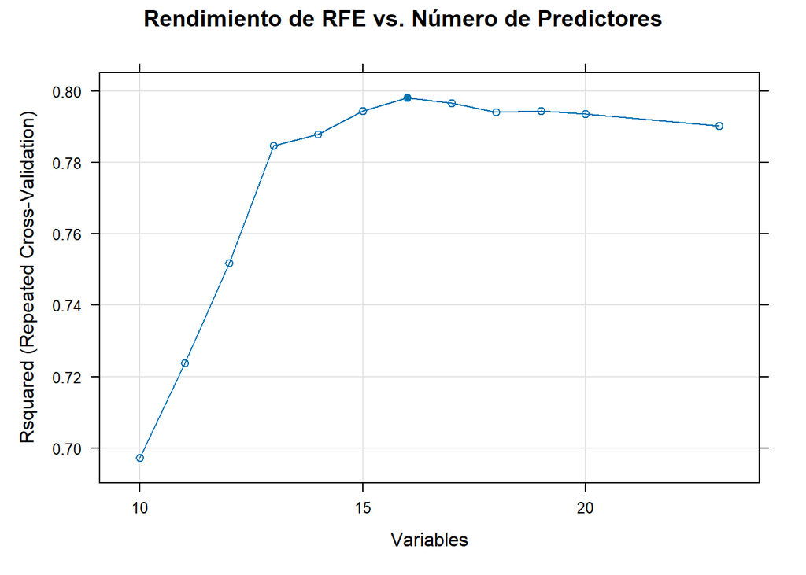

```r
# Obtener la lista de los mejores predictores seleccionados
mejores_predictores_imc <- predictors(rfe_resultados)

# Visualizar el rendimiento de los modelos

plot(rfe_resultados, type = c("g", "o"), main = "Rendimiento de RFE vs. Número de Predictores")
```

```r
# 5. Evaluar el modelo final de regresión lineal
# El modelo final ya está entrenado dentro del objeto rfe_resultados
cat("\n--- Resumen del Modelo Final de Regresión Lineal ---\n")
```

```
##
## --- Resumen del Modelo Final de Regresión Lineal ---
```

```r
# Recrear el modelo lineal con los predictores seleccionados para poder usar las funciones del paquete car
# Crear la fórmula del modelo con los predictores seleccionados
formula_final <- as.formula(paste("imc ~", paste(mejores_predictores_imc, collapse = " + ")))
rm <- lm(formula_final, data = muestra)
summary(rm)
```

```
##
## Call:
## lm(formula = formula_final, data = muestra)
##
## Residuals:
##      Min       1Q   Median       3Q      Max
## -3.06895 -0.81820 -0.00255  0.89432  3.02599
##
## Coefficients:
##                     Estimate Std. Error t value Pr(>|t|)
## (Intercept)         -3.36880    3.07131  -1.097  0.27588
## Gender              -1.17782    0.61649  -1.911  0.05952 .
## Wrists.diameter     -0.41470    0.34756  -1.193  0.23621
## Elbows.diameter     -0.22681    0.24731  -0.917  0.36176
## Ankle.Minimum.Girth -0.20254    0.13994  -1.447  0.15158
## Wrist.Minimum.Girth  0.12114    0.34334   0.353  0.72511
## Forearm.Girth        0.18623    0.18631   1.000  0.32042
## Knees.diameter       0.08498    0.20583   0.413  0.68077
## Biacromial.diameter -0.17294    0.08209  -2.107  0.03816 *
## Thigh.Girth          0.16992    0.05478   3.102  0.00263 **
## Bicep.Girth          0.23185    0.10363   2.237  0.02795 *
## Waist.Girth          0.18370    0.02540   7.233 2.14e-10 ***
## Ankles.diameter      0.01409    0.19960   0.071  0.94390
## Chest.depth         -0.07579    0.08292  -0.914  0.36337
## Calf.Maximum.Girth   0.09729    0.09459   1.029  0.30669
## Chest.diameter       0.17196    0.09317   1.846  0.06850 .
## Biiliac.diameter    -0.02313    0.07479  -0.309  0.75783
## ---
## Signif. codes:  0 '***' 0.001 '**' 0.01 '*' 0.05 '.' 0.1 ' ' 1
##
## Residual standard error: 1.22 on 83 degrees of freedom
## Multiple R-squared:  0.8739, Adjusted R-squared:  0.8495
## F-statistic: 35.94 on 16 and 83 DF,  p-value: < 2.2e-16
```

Revisaremos como es habitual en la implementacion de estos modelos la confiabilidad de este.

recordando las condiciones que se deben cumplir para que un modelo de regresión lineal múltiple sea confiable:

1. variable de salida/respuesta continua y cuantitativa: se cumple ya que el imc es un indice numerico y continuo.
2. Los predictores deben ser cuantitativos o dicotómicos: se cumple ya que los predictores son todos cuantitativos.
3. Los predictores deben tener algún grado de variabilidad, es decir, no son constantes: se cumple ya que todos los predictores tienen varianza distinta de cero.

```r
for (i in mejores_predictores_imc) {
  cat("Varianza de", i, ":", var(muestra[[i]]), "\n")
}
```

```
## Varianza de Gender : 0.2516162
## Varianza de Wrists.diameter : 0.9996404
## Varianza de Elbows.diameter : 1.957269
## Varianza de Ankle.Minimum.Girth : 3.683567
## Varianza de Wrist.Minimum.Girth : 1.842928
## Varianza de Forearm.Girth : 7.913939
## Varianza de Knees.diameter : 1.737673
## Varianza de Biacromial.diameter : 8.210847
## Varianza de Thigh.Girth : 16.08452
## Varianza de Bicep.Girth : 17.52929
## Varianza de Waist.Girth : 129.7375
## Varianza de Ankles.diameter : 1.945102
## Varianza de Chest.depth : 6.978586
## Varianza de Calf.Maximum.Girth : 7.112582
## Varianza de Chest.diameter : 7.389773
## Varianza de Biiliac.diameter : 4.355802
```

como podemos observar ningun predictor observado tiene un grado de variabilidad nulo, por lo que se cumple la condicion.

ahora en el analizis se verificaran la condicion 4, 5 y 6

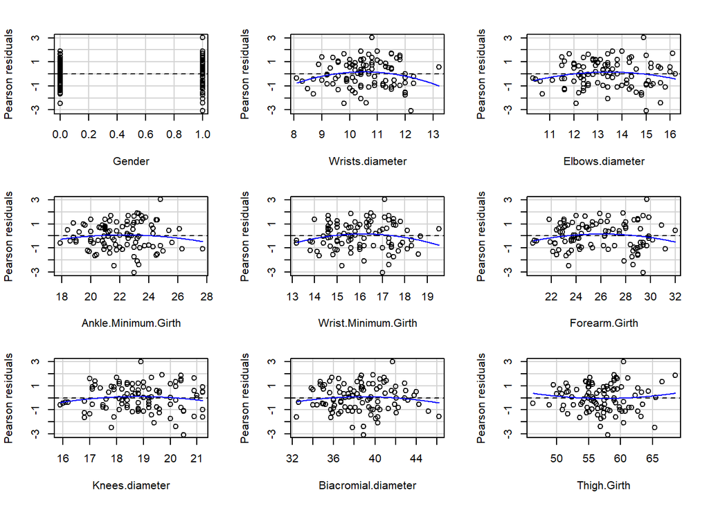

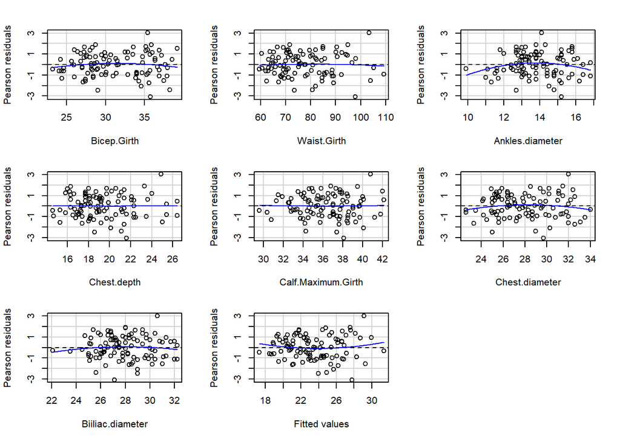

```
##                     Test stat Pr(>|Test stat|)
## Gender                 0.4365           0.6636
## Wrists.diameter       -1.8536           0.0674 .
## Elbows.diameter       -1.5178           0.1329
## Ankle.Minimum.Girth   -0.8723           0.3856
## Wrist.Minimum.Girth   -1.5596           0.1227
## Forearm.Girth         -1.1814           0.2409
## Knees.diameter        -1.0946           0.2769
## Biacromial.diameter   -0.8449           0.4006
## Thigh.Girth            0.7773           0.4392
## Bicep.Girth           -0.8237           0.4125
## Waist.Girth           -0.3411           0.7339
## Ankles.diameter       -1.7872           0.0776 .
## Chest.depth            0.0824           0.9346
## Calf.Maximum.Girth     0.1397           0.8893
## Chest.diameter        -1.0116           0.3147
## Biiliac.diameter      -0.7523           0.4540
## Tukey test             1.1084           0.2677
## ---
## Signif. codes:  0 '***' 0.001 '**' 0.01 '*' 0.05 '.' 0.1 ' ' 1
```

```r
# 4. Cada predictor debe estar relacionado linealmente con la respuesta.
residualPlots(rm)
```

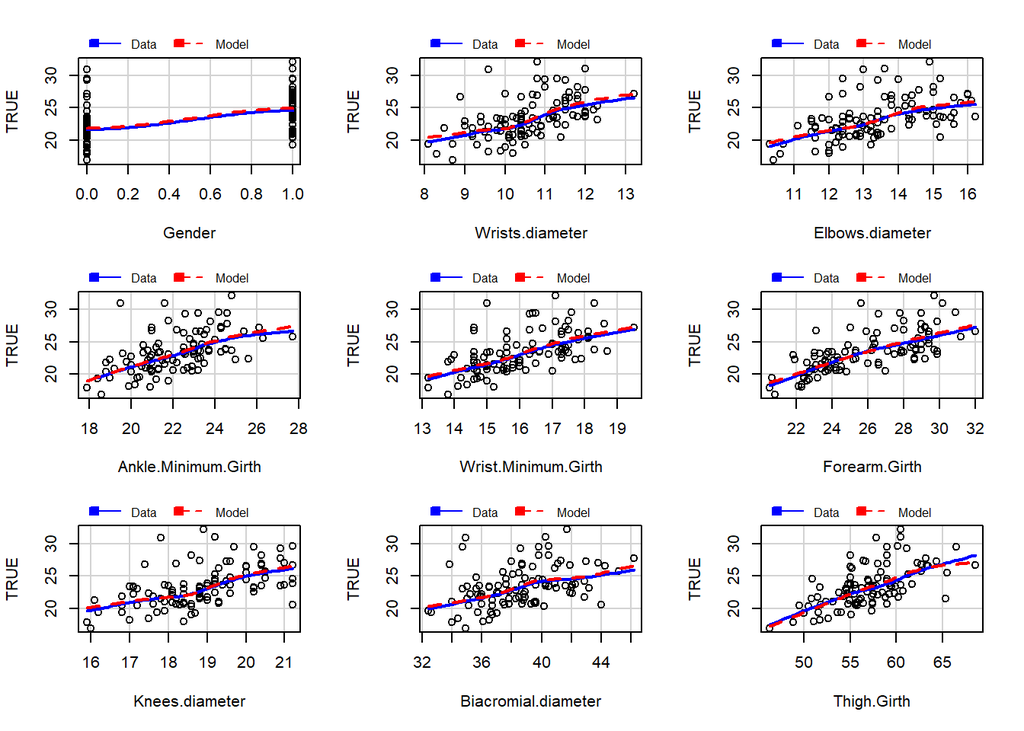

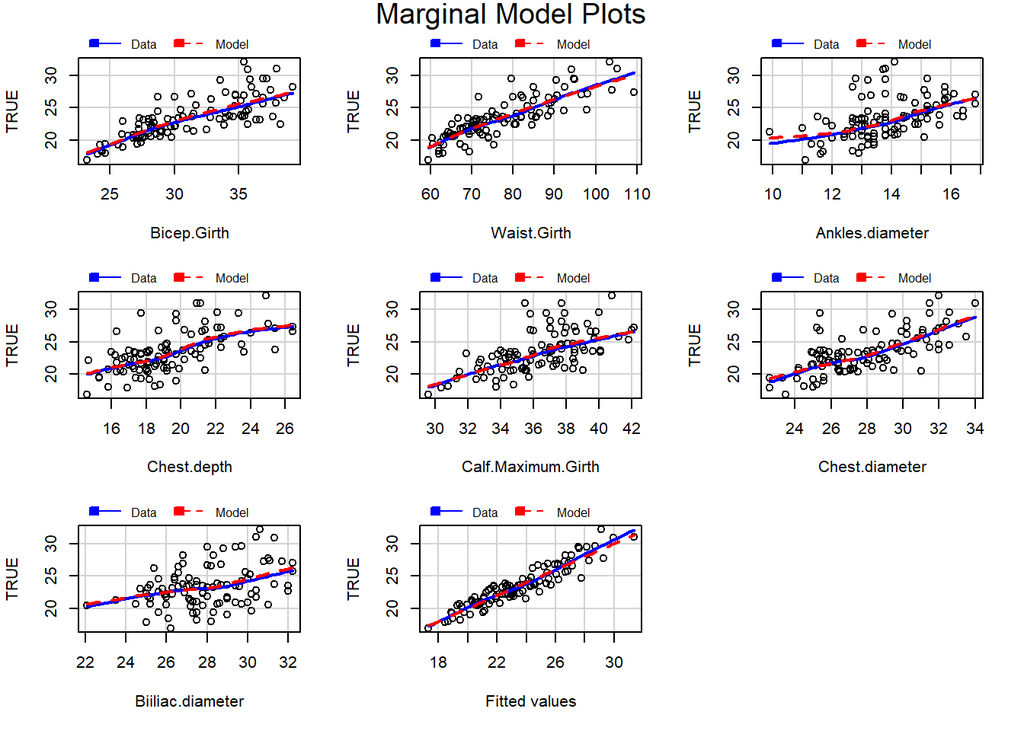

```r
marginalModelPlots(rm)
```

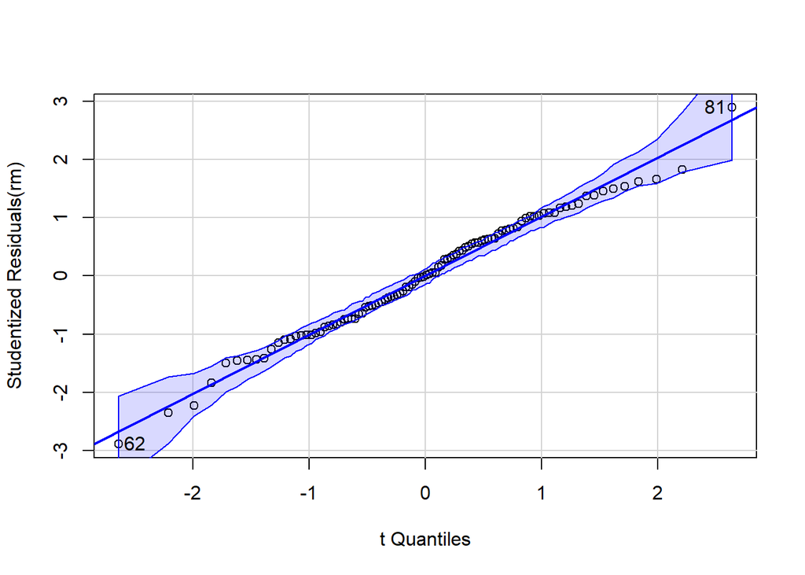

```
## [1] 62 81
```

```r
# 5. La distribución de los residuos debe ser cercana a la normal centrada en cero.
qqPlot(rm)
```

```r
# 6. La variabilidad de los residuos debe ser constante (homocedasticidad).
ncvTest(rm)
```

```
## Non-constant Variance Score Test
## Variance formula: ~ fitted.values
## Chisquare = 9.494513, Df = 1, p = 0.0020609
```

Como se puede observar la mayoria de las variables predictoras representa una relacion lineal con la variable de respuesta, esto se reafirma con el test de cruvatura donde ninguna presento un p-valor significativo lo que indica que no hay evidencia suficiente para rechazar la hipotesis nula de linealidad. Por otra parte, el grafico Q-Q muestra que los residuos se distribuyen normalmente centrados en cero, lo que indica que la condicion 5 se cumple. Finalmente, el test de homocedasticidad indica que la variabilidad de los residuos no es constante, por lo que la sexta condicion no se cumple.

Ahora se verificara la condicion 7 la independencia de los residuos, para esto se aplicara el test de Durbin-Watson.

```r
durbinWatsonTest(rm)
```

```
##  lag Autocorrelation D-W Statistic p-value
##    1      -0.1306557       2.23999   0.234
##  Alternative hypothesis: rho != 0
```

se falla al rechazar la hipotesis nula de independencia de los residuos, por lo que se cumple la condicion 7.

verificando que no exista multicolinealidad entre los predictores, para esto se aplicara el test VIF.

```r
vif(rm)
```

```
##              Gender     Wrists.diameter     Elbows.diameter Ankle.Minimum.Girth
##            6.358427            8.029099            7.959774            4.796334
## Wrist.Minimum.Girth       Forearm.Girth      Knees.diameter Biacromial.diameter
##           14.444850           18.264906            4.895018            3.678858
##         Thigh.Girth         Bicep.Girth         Waist.Girth     Ankles.diameter
##            3.209233           12.516564            5.564474            5.152758
##         Chest.depth  Calf.Maximum.Girth      Chest.diameter    Biiliac.diameter
##            3.190262            4.231586            4.264813            1.619832
```

los resultados obtenidos son alarmantes cuanto menos ya que un par de variables predictoras arrojaron un valor VIF mayor a 10, lo que es un valor significativo de multicolinealidad, lo que indica que el modelo no cumple con la condicion 8.

finalmente con la influencia de los valores atipicos se realizara el analisis con la funcion influencePlot del paquete car, para ver si existen valores atipicos o influyentes que puedan afectar el modelo.

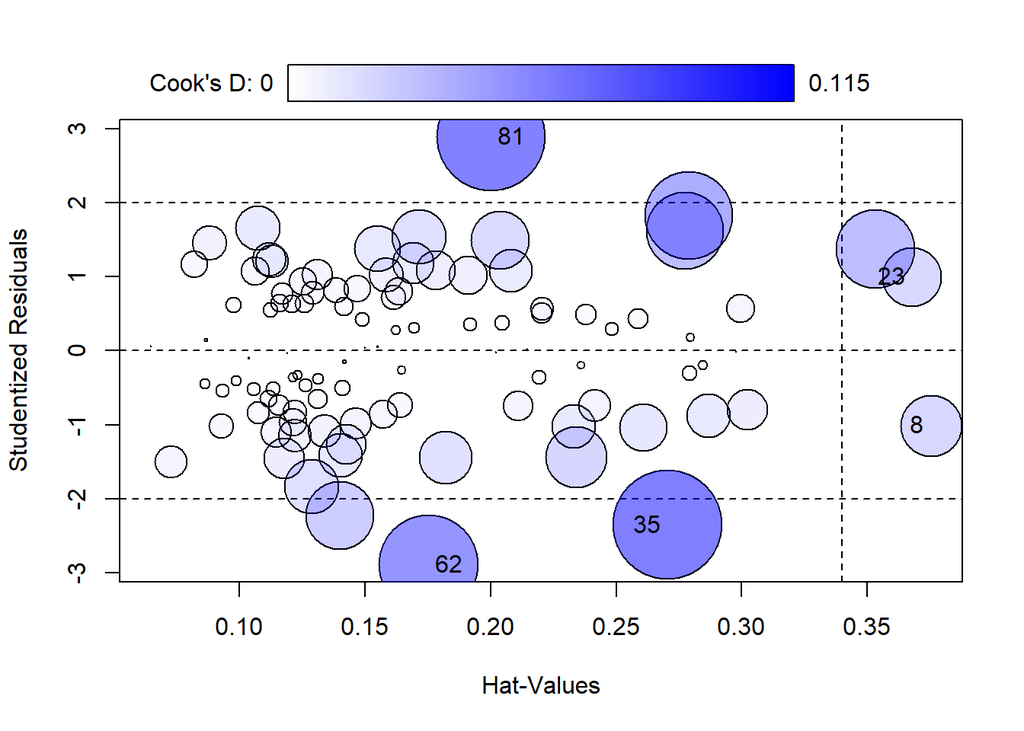

```
##       StudRes       Hat      CookD
## 8  -1.0097537 0.3754236 0.03604254
## 23  0.9964088 0.3679003 0.03399447
## 35 -2.3567969 0.2705667 0.11489043
## 62 -2.8890862 0.1750725 0.09572813
## 81  2.8929175 0.1999327 0.11298982
```

```r
influencePlot(rm)
```

como observamos en los resultados ninguno de los valores atipicos influyen en el modelo, por lo que se cumple la condicion 9.

A modo de conclusion se puede decir que el modelo no es confiable debido a que no cumple con la condicion 6, ya que la variabilidad de los residuos no es constante, y tampoco cumple con la condicion 8, ya que existe multicolinealidad entre los predictores. Por lo tanto, se recomienda realizar una nueva seleccion de variables para el modelo, eliminando las variables que presenten multicolinealidad y realizando un nuevo analisis de confiabilidad.

a pesar de lo anterior se evaluara la calidad predictiva del modelo.

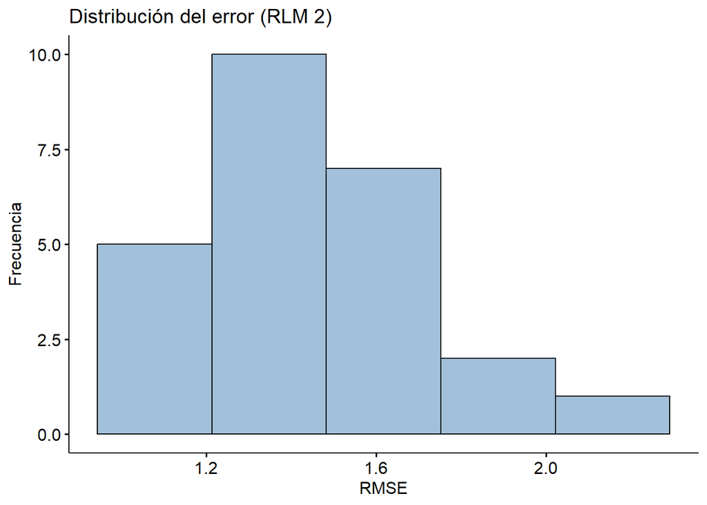

```r
# Prepara el data frame con los valores de RMSE
rlm2_err_df <- data.frame(RMSE = rfe_resultados[["resample"]][["RMSE"]])

# Crea el histograma usando el data frame recién creado
rlm2_err_p <- gghistogram(data = rlm2_err_df,
                          x = "RMSE",
                          bins = 5,
                          fill = "steelblue",
                          ylab = "Frecuencia",
                          title = "Distribución del error (RLM 2)")

# Imprime el gráfico
print(rlm2_err_p)
```

```r
cat("Rendimiento del modelo de RLM con predictores seleccionados por RFE:\n")
```

```
## Rendimiento del modelo de RLM con predictores seleccionados por RFE:
```

```r
rendimiento_optimo <- rfe_resultados$results[rfe_resultados$results$Variables == rfe_resultados$optsize, ]
print(rendimiento_optimo, digits = 3)
```

```
##   Variables RMSE Rsquared MAE RMSESD RsquaredSD MAESD
## 7        16 1.45    0.798 1.2   0.25     0.0882 0.205
```

```r
cat("\nMás detalle de la raíz del error cuadrático medio (RMSE) de las remuestras:\n")
```

```
##
## Más detalle de la raíz del error cuadrático medio (RMSE) de las remuestras:
```

```r
# describe() funciona bien con el data frame rlm2_err_df que contiene la columna RMSE
print(describe(rlm2_err_df, trim = 0, quant = c(0.25, 0.75),
               skew = FALSE, IQR = TRUE), digits = 3)
```

```
##      vars  n mean   sd median   min   max range   se   IQR Q0.25 Q0.75
## RMSE    1 25 1.45 0.25  1.433 1.006 2.084 1.078 0.05 0.275 1.286 1.561
```

#### Usando RFE, construir un modelo de regresión logística múltiple para la variable EN que incluya el conjunto de predictores, entre dos y seis, que entregue la mejor curva ROC y que utilice validación cruzada dejando uno fuera para evitar el sobreajuste (obviamente no se debe considerar las variables Peso, Estatura –Weight y Height respectivamente– ni IMC).

```r
set.seed(19647)

# Seleccionar predictores y variable respuesta
predictores_en = setdiff(colnames(muestra), c("imc", "en", "Weight", "Height"))
x_en = muestra[, predictores_en, drop = FALSE]

# Convertir variable respuesta a factor con nombres válidos
y_en = factor(muestra$en,
               levels = c(0, 1),
               labels = c("No_EN", "Si_EN"))

# Control para el RFE
ctrl_loocv <- rfeControl(
  functions = lrFuncs,
  method = "LOOCV",
  verbose = FALSE,
  returnResamp = "final"
)

# Train para RFE
trainp5 = trainControl(
  method = "none",
  classProbs = TRUE,
  summaryFunction = twoClassSummary
)

# cantidad de predictores a usar en RFE
subset_sizes = 2:6

# RFE
rfe_resultados <- suppressWarnings(rfe(
  x = x_en,
  y = y_en,
  sizes = subset_sizes,
  rfeControl = ctrl_loocv,
  trControl = trainp5,
  metric = "ROC"
))

print(rfe_resultados)
```

```
##
## Recursive feature selection
##
## Outer resampling method: Leave-One-Out Cross-Validation
##
## Resampling performance over subset size:
##
##  Variables Accuracy Kappa Selected
##          2     0.82  0.64
##          3     0.83  0.66        *
##          4     0.81  0.62
##          5     0.83  0.66
##          6     0.80  0.60
##         23     0.80  0.60
##
## The top 3 variables (out of 3):
##    Hip.Girth, Bicep.Girth, Biiliac.diameter
```

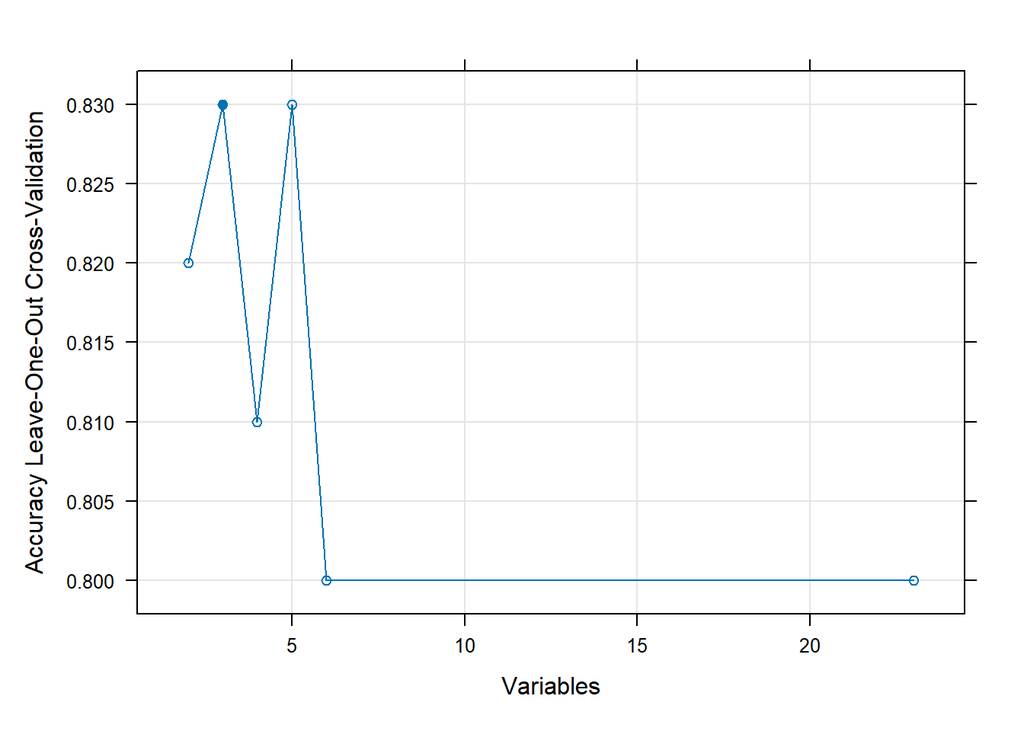

```r
plot(rfe_resultados, type = c("g", "o"))
```

```r
cat("\nPredictores seleccionados:", predictors(rfe_resultados), "\n")
```

```
##
## Predictores seleccionados: Hip.Girth Bicep.Girth Biiliac.diameter
```

```r
# Entrenar modelo final con predictores seleccionados
mejores_predictores_p5 <- predictors(rfe_resultados)
modelo_final_p5 <- glm(y_en ~ .,
                   data = data.frame(x_en[, mejores_predictores_p5, drop = FALSE], y_en),
                   family = binomial)

cat("\n--- Resumen del Modelo Final ---\n")
```

```
##
## --- Resumen del Modelo Final ---
```

```r
summary(modelo_final_p5)
```

```
##
## Call:
## glm(formula = y_en ~ ., family = binomial, data = data.frame(x_en[,
##     mejores_predictores_p5, drop = FALSE], y_en))
##
## Coefficients:
##                   Estimate Std. Error z value Pr(>|z|)
## (Intercept)      -44.05107    9.95645  -4.424 9.67e-06 ***
## Hip.Girth          0.32871    0.10224   3.215 0.001303 **
## Bicep.Girth        0.32792    0.09052   3.623 0.000291 ***
## Biiliac.diameter   0.07163    0.17112   0.419 0.675533
## ---
## Signif. codes:  0 '***' 0.001 '**' 0.01 '*' 0.05 '.' 0.1 ' ' 1
##
## (Dispersion parameter for binomial family taken to be 1)
##
##     Null deviance: 138.629  on 99  degrees of freedom
## Residual deviance:  67.325  on 96  degrees of freedom
## AIC: 75.325
##
## Number of Fisher Scoring iterations: 6
```

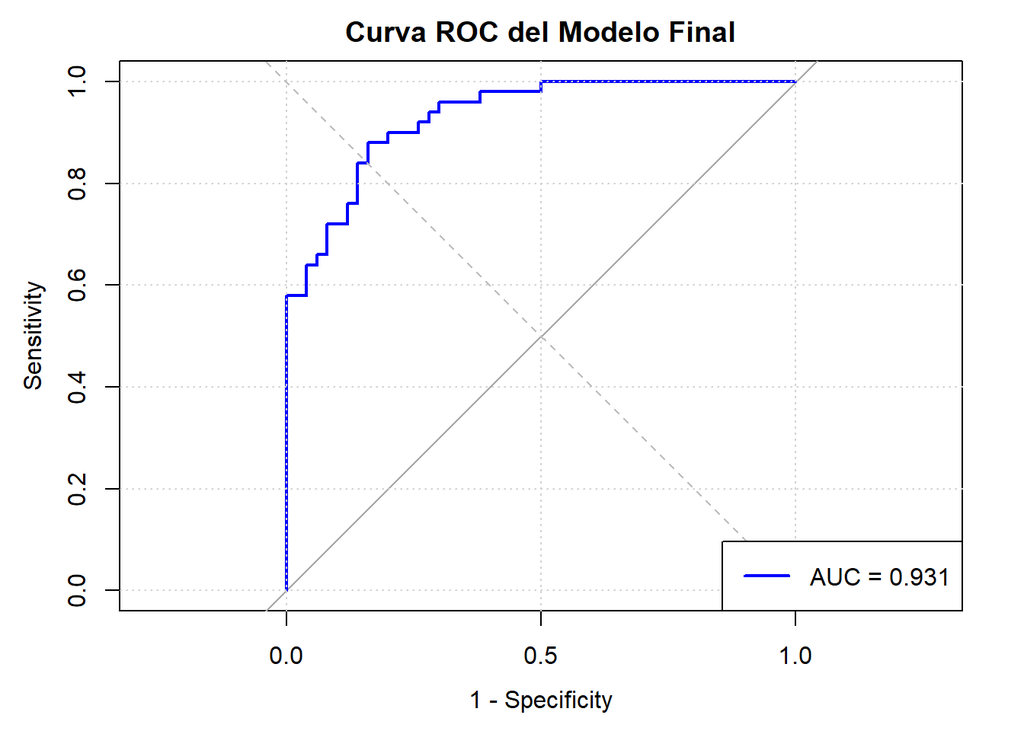

```r
# Calcular probabilidades y clase predicha
probabilidades <- predict(modelo_final_p5, type = "response")
prediccion_clase <- factor(ifelse(probabilidades > 0.5, "Si_EN", "No_EN"),
                           levels = c("No_EN", "Si_EN"))

# Calcular curva ROC y AUC
roc_curve <- roc(response = y_en, predictor = probabilidades, levels = c("No_EN", "Si_EN"))
auc_value <- auc(roc_curve)

# Mejorar gráfico de curva ROC
plot(roc_curve,
     main = "Curva ROC del Modelo Final",
     col = "blue",
     lwd = 2,
     legacy.axes = TRUE)  # Eje x: 0-1 en lugar de 1-0
grid()
abline(a = 0, b = 1, lty = 2, col = "gray")  # Línea de referencia
legend("bottomright",
       legend = paste("AUC =", round(auc_value, 3)),
       col = "blue",
       lwd = 2)
```

```r
# Calcular matriz de confusión

conf_matrix <- confusionMatrix(prediccion_clase, y_en, positive = "Si_EN")
cat("\n--- Matriz de Confusión ---\n")
```

```
##
## --- Matriz de Confusión ---
```

```r
print(conf_matrix)
```

```
## Confusion Matrix and Statistics
##
##           Reference
## Prediction No_EN Si_EN
##      No_EN    42     7
##      Si_EN     8    43
##
##                Accuracy : 0.85
##                  95% CI : (0.7647, 0.9135)
##     No Information Rate : 0.5
##     P-Value [Acc > NIR] : 2.413e-13
##
##                   Kappa : 0.7
##
##  Mcnemar's Test P-Value : 1
##
##             Sensitivity : 0.8600
##             Specificity : 0.8400
##          Pos Pred Value : 0.8431
##          Neg Pred Value : 0.8571
##              Prevalence : 0.5000
##          Detection Rate : 0.4300
##    Detection Prevalence : 0.5100
##       Balanced Accuracy : 0.8500
##
##        'Positive' Class : Si_EN
##
```

```r
umbral_optimo <- coords(roc_curve, "best", ret = "threshold", best.method = "youden")$threshold
cat("\nUmbral óptimo (Youden):", round(umbral_optimo, 3), "\n")
```

```
##
## Umbral óptimo (Youden): 0.43
```

```r
prediccion_optima <- factor(ifelse(probabilidades > umbral_optimo, "Si_EN", "No_EN"),
                            levels = c("No_EN", "Si_EN"))

conf_matrix_optima <- confusionMatrix(prediccion_optima, y_en, positive = "Si_EN")


# Mostrar métricas clave

cat("\n--- Métricas con Umbral 0.5 ---\n")
```

```
##
## --- Métricas con Umbral 0.5 ---
```

```r
cat("Exactitud:", round(conf_matrix$overall['Accuracy'], 3), "\n")
```

```
## Exactitud: 0.85
```

```r
cat("Sensibilidad:", round(conf_matrix$byClass['Sensitivity'], 3), "\n")
```

```
## Sensibilidad: 0.86
```

```r
cat("Especificidad:", round(conf_matrix$byClass['Specificity'], 3), "\n")
```

```
## Especificidad: 0.84
```

```r
cat("Precisión:", round(conf_matrix$byClass['Precision'], 3), "\n")
```

```
## Precisión: 0.843
```

```r
cat("F1-score:", round(conf_matrix$byClass['F1'], 3), "\n")
```

```
## F1-score: 0.851
```

```r
cat("\n--- Métricas con Umbral Óptimo (", round(umbral_optimo, 3), ") ---\n")
```

```
##
## --- Métricas con Umbral Óptimo ( 0.43 ) ---
```

```r
cat("Exactitud (Accuracy):", round(conf_matrix_optima$overall['Accuracy'], 3), "\n")
```

```
## Exactitud (Accuracy): 0.86
```

```r
cat("Sensibilidad (Recall):", round(conf_matrix_optima$byClass['Sensitivity'], 3), "\n")
```

```
## Sensibilidad (Recall): 0.88
```

```r
cat("Especificidad:", round(conf_matrix_optima$byClass['Specificity'], 3), "\n")
```

```
## Especificidad: 0.84
```

```r
cat("Precisión:", round(conf_matrix_optima$byClass['Precision'], 3), "\n")
```

```
## Precisión: 0.846
```

```r
cat("F1-score:", round(conf_matrix_optima$byClass['F1'], 3), "\n")
```

```
## F1-score: 0.863
```

### Pronunciarse sobre la confiabilidad y el poder predictivo de los modelos obtenidos.

### Relación lineal entre predictores

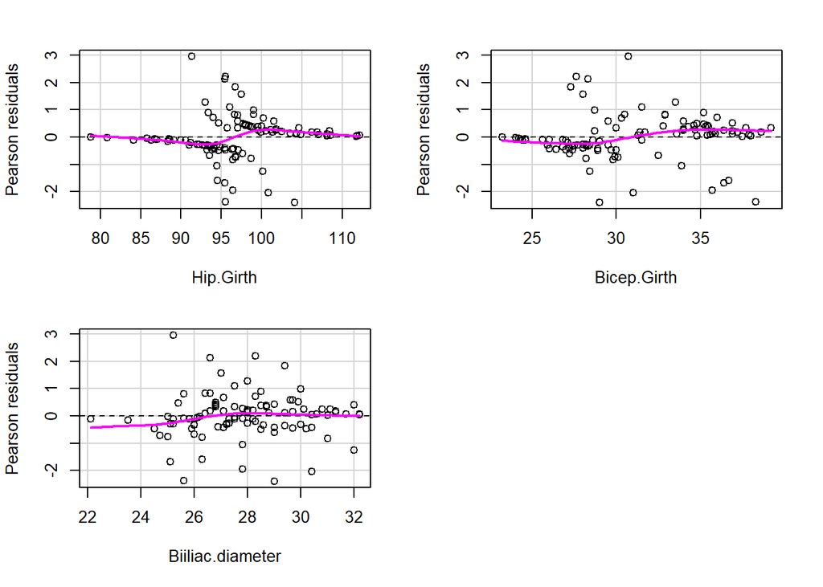

```
##                  Test stat Pr(>|Test stat|)
## Hip.Girth           0.0437          0.83434
## Bicep.Girth         2.2652          0.13231
## Biiliac.diameter    4.1095          0.04264 *
## ---
## Signif. codes:  0 '***' 0.001 '**' 0.01 '*' 0.05 '.' 0.1 ' ' 1
```

```r
residualPlots(modelo_final_p5,
              fitted = FALSE)
```

### Multicolinealidad

Notemos que los valores de multicolinealidad de los predictores del modelo final obtenido con RFE son menores a 5, inclusive, muy cercanos a 1, lo que indica que no existe multicolinealidad entre los predictores.

```r
vif(modelo_final_p5)
```

```
##        Hip.Girth      Bicep.Girth Biiliac.diameter
##         1.099430         1.026212         1.113299
```

### Residuos independientes entre si

```r
durbinWatsonTest(modelo_final_p5)
```

```
##  lag Autocorrelation D-W Statistic p-value
##    1     -0.06910558       2.13401   0.496
##  Alternative hypothesis: rho != 0
```

### Los datos no se encuentran influenciados

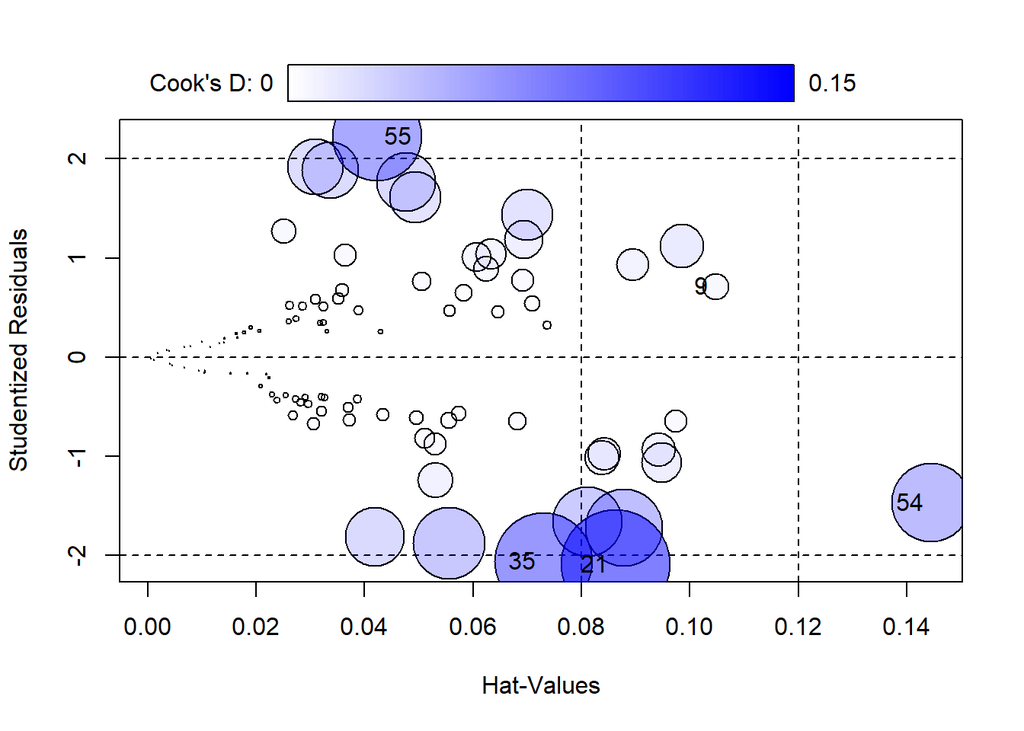

```
##       StudRes        Hat       CookD
## 9   0.7103998 0.10469087 0.008720698
## 21 -2.0917623 0.08631885 0.149508299
## 35 -2.0590014 0.07295752 0.120224700
## 54 -1.4709428 0.14445175 0.078021916
## 55  2.2218915 0.04228216 0.100652928
```

```r
influencePlot(modelo_final_p5)
```

### Información incompleta

```r
predictores <- predictors(modelo_final_p5)
for (pred in predictores) {
  cat("Variable:", pred, "\n")
  cat("Número de observaciones por nivel de la variable de respuesta:\n")
  print(table(muestra[[pred]]))
  cat("\n")
}
```

```
## Variable: Hip.Girth
## Número de observaciones por nivel de la variable de respuesta:
##
##  78.8  80.9  84.1  85.8  86.3  86.8    87  88.4  88.5  88.6  89.1    90  90.6
##     1     1     1     1     1     1     1     1     2     1     1     1     1
##    91  91.2  91.3    92  92.2  92.7    93  93.2  93.3  93.4  93.5  93.7  93.8
##     1     1     1     1     1     1     2     1     1     1     3     1     1
##    94  94.1  94.4  94.5  94.7  94.8  95.4  95.5  95.7    96  96.3  96.4  96.5
##     1     2     2     1     2     1     3     3     1     1     1     2     1
##  96.6  96.7  96.8    97  97.1  97.5  97.6  97.7  97.9    98  98.4  98.6  98.7
##     1     2     1     3     1     1     1     1     1     1     1     1     1
##  98.8    99  99.5  99.6  99.9   100 100.1 100.2 100.5 100.8 101.1 101.3 101.5
##     1     2     1     1     1     1     1     1     1     1     1     1     1
## 101.7 101.8 102.5 103.5 104.1 104.3 104.6 104.8 106.2 106.9   107 108.1 108.4
##     1     1     1     1     1     2     1     1     1     1     1     2     1
## 108.5 111.7 111.8 112.1
##     1     1     1     1
##
## Variable: Bicep.Girth
## Número de observaciones por nivel de la variable de respuesta:
##
## 23.2   24 24.2 24.3 24.4 24.6 25.6 25.9   26 26.4 26.8   27 27.1 27.2 27.3 27.4
##    1    1    1    1    1    2    1    1    2    1    2    2    1    2    1    2
## 27.5 27.6 27.7   28 28.2 28.3 28.4 28.6 28.7 28.9   29 29.5 29.7 29.8 29.9   30
##    1    1    1    3    3    2    2    1    2    2    2    2    1    1    1    2
## 30.1 30.3 30.5 30.7   31 31.3 31.4 31.5 31.7 32.5 32.8 32.9 33.5 33.6 33.9   34
##    1    1    1    1    1    1    1    2    1    1    1    2    1    1    1    3
## 34.3 34.6 34.7 34.8 35.2 35.3 35.4 35.5 35.6 35.7 35.8 35.9   36 36.4 36.7 36.9
##    1    1    1    2    2    1    2    1    1    2    1    1    1    2    1    3
## 37.2 37.5 37.7 37.9   38 38.3 38.6 39.2
##    1    1    1    1    1    1    1    1
##
## Variable: Biiliac.diameter
## Número de observaciones por nivel de la variable de respuesta:
##
## 22.1 23.5 24.5 24.7   25 25.1 25.2 25.4 25.6 25.8 25.9   26 26.1 26.2 26.3 26.4
##    1    1    1    1    2    2    3    1    3    1    1    3    1    1    2    2
## 26.6 26.8 26.9   27 27.1 27.2 27.3 27.5 27.8   28 28.2 28.3 28.5 28.6 28.7 28.8
##    3    4    1    1    3    2    2    5    4    5    2    3    3    1    2    1
##   29 29.4 29.6 29.7 29.9   30 30.1 30.2 30.4 30.6 30.8   31 31.1 31.3 31.7   32
##    4    3    1    3    1    2    1    2    3    1    1    2    1    2    1    2
## 32.2
##    2
```

### Separación perfecta

En los gráficos de residuos del modelo final obtenido con RFE, se puede observar que las rectas ajustadas no están desviadas de la curva local de ajuste de los datos, lo que indica que no hay separación perfecta. Esto sugiere que el modelo es capaz de capturar la relación entre los predictores y la variable de respuesta sin problemas de separación perfecta.